# Assessment1.3

"Divya Kasturi s4654177

30/05/2021

#Data Viz and Wrangling #Reading the libraries tidyverse, skimr and scales

```r
library(tidyverse)
library(skimr)
library(scales)
```

#Reading the dataset fastfood

```r
fastfood<-read_csv("https://raw.githubusercontent.com/rfordatascience/tidytuesday/master/data/2018/2018-09-04/fastfood_calories.csv")
```

#identifying the different types of variables using skimr packages.In the recorded data every variable has a pre-defined data type, along with the specific range mentioned with min and max(=variability). #Salads,x column can be removed from the data set as they are unused.

```r
skim(fastfood)
```

Data summary

| Name | fastfood |
| --- | --- |
| Number of rows | 515 |
| Number of columns | 18 |
| _______________________ |  |
| Column type frequency: |  |
| character | 3 |
| numeric | 15 |
| ________________________ |  |
| Group variables | None |

**Variable type: character**

| skim_variable | n_missing | complete_rate | min | max | empty | n_unique | whitespace |
| --- | --- | --- | --- | --- | --- | --- | --- |
| restaurant | 0 | 1 | 5 | 11 | 0 | 8 | 0 |
| item | 0 | 1 | 5 | 63 | 0 | 505 | 0 |
| salad | 0 | 1 | 5 | 5 | 0 | 1 | 0 |

**Variable type: numeric**

| skim_variable | n_missing | complete_rate | mean | sd | p0 | p25 | p50 | p75 | p100 | hist |
| --- | --- | --- | --- | --- | --- | --- | --- | --- | --- | --- |
| X1 | 0 | 1.00 | 258.00 | 148.81 | 1 | 129.5 | 258.0 | 386.5 | 515 | ▇▇▇▇▇ |
| calories | 0 | 1.00 | 530.91 | 282.44 | 20 | 330.0 | 490.0 | 690.0 | 2430 | ▇▆▁▁▁ |
| cal_fat | 0 | 1.00 | 238.81 | 166.41 | 0 | 120.0 | 210.0 | 310.0 | 1270 | ▇▃▁▁▁ |
| total_fat | 0 | 1.00 | 26.59 | 18.41 | 0 | 14.0 | 23.0 | 35.0 | 141 | ▇▃▁▁▁ |
| sat_fat | 0 | 1.00 | 8.15 | 6.42 | 0 | 4.0 | 7.0 | 11.0 | 47 | ▇▃▁▁▁ |
| trans_fat | 0 | 1.00 | 0.47 | 0.84 | 0 | 0.0 | 0.0 | 1.0 | 8 | ▇▁▁▁▁ |
| cholesterol | 0 | 1.00 | 72.46 | 63.16 | 0 | 35.0 | 60.0 | 95.0 | 805 | ▇▁▁▁▁ |
| sodium | 0 | 1.00 | 1246.74 | 689.95 | 15 | 800.0 | 1110.0 | 1550.0 | 6080 | ▇▆▁▁▁ |
| total_carb | 0 | 1.00 | 45.66 | 24.88 | 0 | 28.5 | 44.0 | 57.0 | 156 | ▅▇▂▁▁ |
| fiber | 12 | 0.98 | 4.14 | 3.04 | 0 | 2.0 | 3.0 | 5.0 | 17 | ▇▅▂▁▁ |
| sugar | 0 | 1.00 | 7.26 | 6.76 | 0 | 3.0 | 6.0 | 9.0 | 87 | ▇▁▁▁▁ |
| protein | 1 | 1.00 | 27.89 | 17.68 | 1 | 16.0 | 24.5 | 36.0 | 186 | ▇▂▁▁▁ |
| vit_a | 214 | 0.58 | 18.86 | 31.38 | 0 | 4.0 | 10.0 | 20.0 | 180 | ▇▁▁▁▁ |
| vit_c | 210 | 0.59 | 20.17 | 30.59 | 0 | 4.0 | 10.0 | 30.0 | 400 | ▇▁▁▁▁ |
| calcium | 210 | 0.59 | 24.85 | 25.52 | 0 | 8.0 | 20.0 | 30.0 | 290 | ▇▁▁▁▁ |

```r
summary(fastfood)
```

```
##        X1         restaurant            item              calories
##  Min.   :  1.0   Length:515         Length:515         Min.   :  20.0
##  1st Qu.:129.5   Class :character   Class :character   1st Qu.: 330.0
##  Median :258.0   Mode  :character   Mode  :character   Median : 490.0
##  Mean   :258.0                                         Mean   : 530.9
##  3rd Qu.:386.5                                         3rd Qu.: 690.0
##  Max.   :515.0                                         Max.   :2430.0
##
##     cal_fat         total_fat         sat_fat         trans_fat
##  Min.   :   0.0   Min.   :  0.00   Min.   : 0.000   Min.   :0.000
##  1st Qu.: 120.0   1st Qu.: 14.00   1st Qu.: 4.000   1st Qu.:0.000
##  Median : 210.0   Median : 23.00   Median : 7.000   Median :0.000
##  Mean   : 238.8   Mean   : 26.59   Mean   : 8.153   Mean   :0.465
##  3rd Qu.: 310.0   3rd Qu.: 35.00   3rd Qu.:11.000   3rd Qu.:1.000
##  Max.   :1270.0   Max.   :141.00   Max.   :47.000   Max.   :8.000
##
##   cholesterol         sodium       total_carb         fiber
##  Min.   :  0.00   Min.   :  15   Min.   :  0.00   Min.   : 0.000
##  1st Qu.: 35.00   1st Qu.: 800   1st Qu.: 28.50   1st Qu.: 2.000
##  Median : 60.00   Median :1110   Median : 44.00   Median : 3.000
##  Mean   : 72.46   Mean   :1247   Mean   : 45.66   Mean   : 4.137
##  3rd Qu.: 95.00   3rd Qu.:1550   3rd Qu.: 57.00   3rd Qu.: 5.000
##  Max.   :805.00   Max.   :6080   Max.   :156.00   Max.   :17.000
##                                                   NA's   :12
##      sugar           protein           vit_a            vit_c
##  Min.   : 0.000   Min.   :  1.00   Min.   :  0.00   Min.   :  0.00
##  1st Qu.: 3.000   1st Qu.: 16.00   1st Qu.:  4.00   1st Qu.:  4.00
##  Median : 6.000   Median : 24.50   Median : 10.00   Median : 10.00
##  Mean   : 7.262   Mean   : 27.89   Mean   : 18.86   Mean   : 20.17
##  3rd Qu.: 9.000   3rd Qu.: 36.00   3rd Qu.: 20.00   3rd Qu.: 30.00
##  Max.   :87.000   Max.   :186.00   Max.   :180.00   Max.   :400.00
##                   NA's   :1        NA's   :214      NA's   :210
##     calcium          salad
##  Min.   :  0.00   Length:515
##  1st Qu.:  8.00   Class :character
##  Median : 20.00   Mode  :character
##  Mean   : 24.85
##  3rd Qu.: 30.00
##  Max.   :290.00
##  NA's   :210
```

#changing the data types of restaurant and salad with as_factor()and defining a class to display the changed data types to factors.

```r
fastfood$restaurant<-as_factor(fastfood$restaurant)
fastfood$salad<-as_factor(fastfood$salad)
class(fastfood$restaurant)
```

```
## [1] "factor"
```

```r
class(fastfood$salad)
```

```
## [1] "factor"
```

#replacing NA with 0 in the dataset fastfood.

```r
fastfood[is.na(fastfood)] <- 0
```

#cut_number makes n groups with the number of observations. #Creating a new variable caloies_type and saving it to the dataset and using cut_number function assigning labels and making them ordered results.

```r
fastfood<-fastfood%>%
  mutate(calories_type=cut_number(calories,3,
                                  labels=c("low","medium","high"),ordered_results=TRUE))
```

#Data viz for calories_type in food items for each type of restaurant. Using facets and theme.

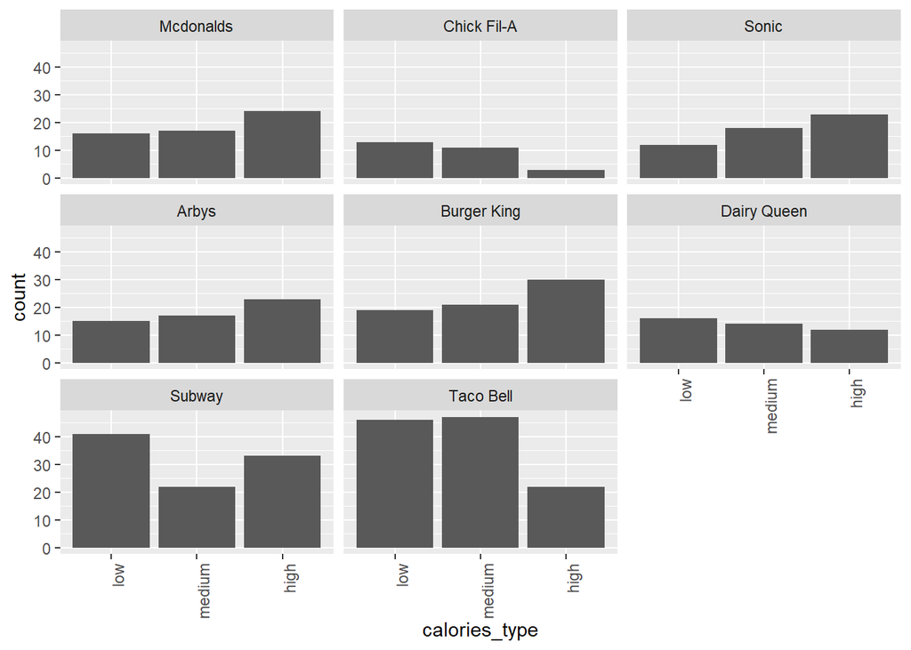

```r
fastfood%>%
  ggplot(aes(calories_type))+
  geom_bar()+
  facet_wrap(~restaurant)+
  theme(axis.text.x = element_text(angle = 90, hjust = 1))
```

#Creating another new variable trans_fat_percentage to calculate the percentage of trans_fat and total_fat.

```r
fastfood<-fastfood%>%mutate(trans_fat_percent = trans_fat/total_fat)
```

#Data viz for rans_fat` in food items for each type of restaurant. Using facets and themes.

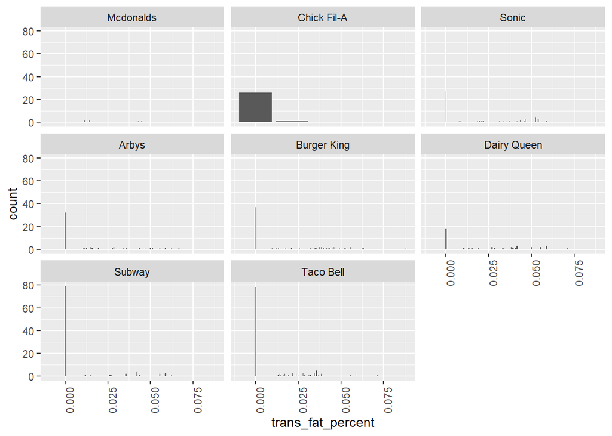

```r
fastfood%>%
  ggplot(aes(trans_fat_percent))+
  geom_bar()+
  facet_wrap(~restaurant)+
  theme(axis.text.x = element_text(angle = 90, hjust = 1))
```

#the average (mean) total_fat for each type of restaurant.

```r
fastfood%>%
  group_by(restaurant)%>%
  mutate(mean(total_fat))%>%
  summarise(total_fat=mean(total_fat))%>%
  ungroup()
```

```
## # A tibble: 8 x 2
##   restaurant  total_fat
##   <fct>           <dbl>
## 1 Mcdonalds        31.8
## 2 Chick Fil-A      16.1
## 3 Sonic            37.6
## 4 Arbys            27.0
## 5 Burger King      36.8
## 6 Dairy Queen      28.9
## 7 Subway           18.5
## 8 Taco Bell        20.9
```

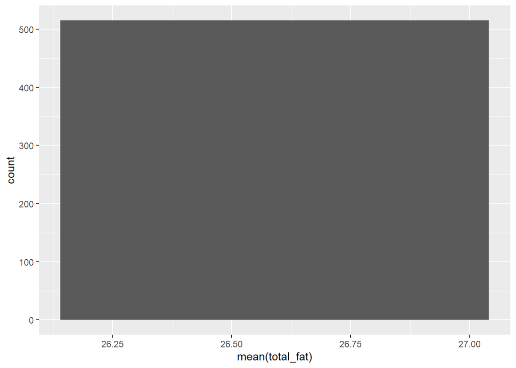

```r
fastfood%>%
  group_by(restaurant)%>%
  ggplot(aes(mean(total_fat)))+
  geom_bar()
```